# Lesson 7: Intro to R

## Aesthetics

Aesthetics is how we want to map the attributes of data to the visual characteristics e.g. axis, colours, size, shape, transparency.

As we want to create a histogram with `MATH` score, we will add `MATH` to x.

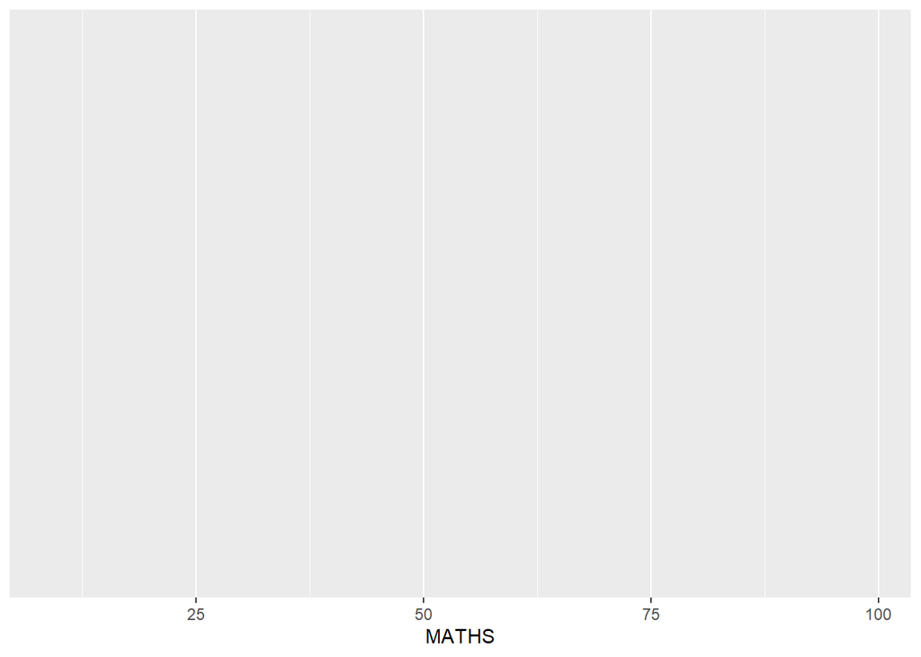

```r
exam_data %>%
  ggplot(aes(x=MATHS))
```

We can see `MATH` score on the x-axis.

## Geometrics

Next we add what sort of plot we want.

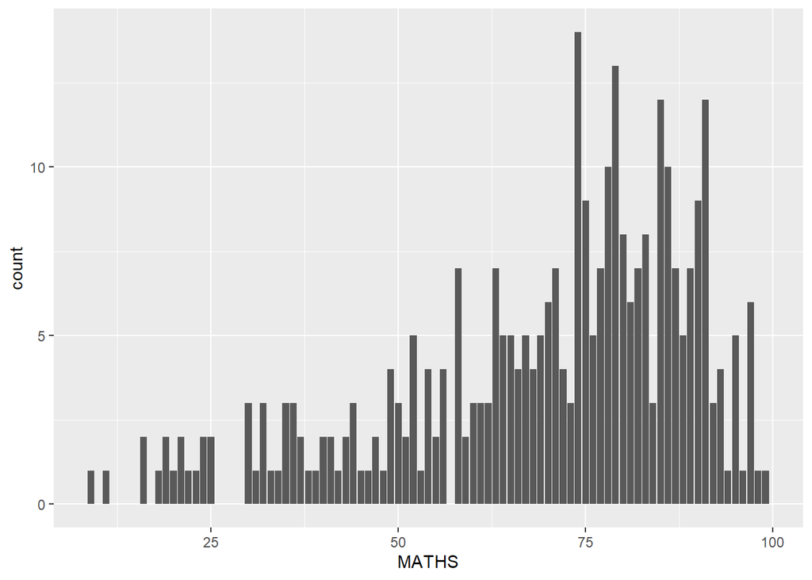

```r
# for a normal bar plot
exam_data %>%
  ggplot(aes(x=MATHS)) +
  geom_bar()
```

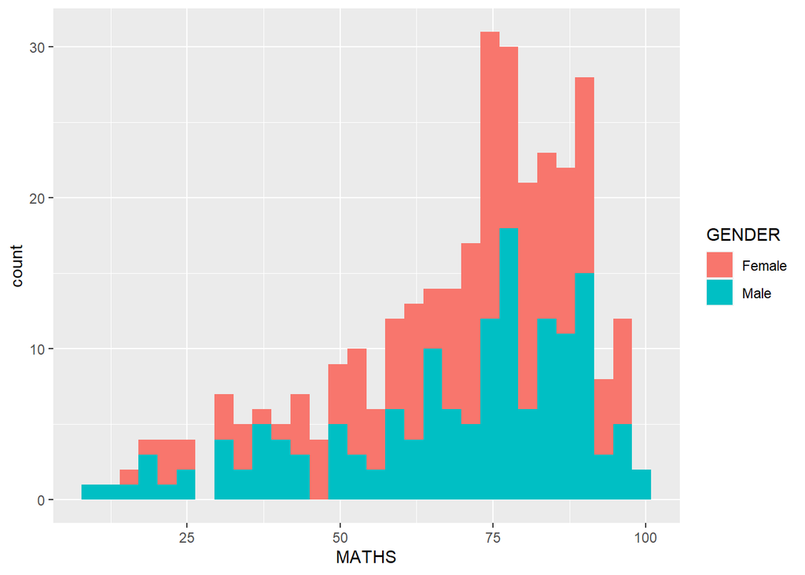

```r
# e.g. we want to split by fill
exam_data %>%
  ggplot(aes(x=MATHS, fill=GENDER)) +
  geom_histogram()
```

Here are the following common options available and simple customization (that I know of and would likely commonly use (something like a cheat sheet for myself)):

### Common Geometric Types

#### geom_point()

- scatter plot (need both x and y)

#### geom_line()

- line plot (need both x and y)

#### geom_col()

- horizontal bar plot (need y)

#### geom_bar()

- vertical bar plot (need x)

#### geom_histogram()

- histogram (need x) Note that the fill in this case fills the bars in the histogram and not in the aesthetic which will split the colours by the different category. this would just make the histogram light blue.

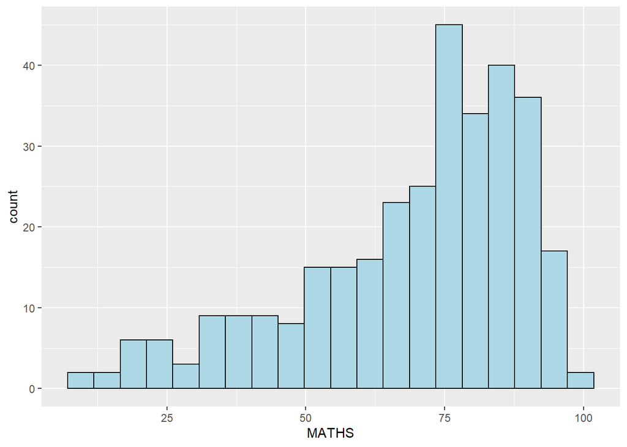

```r
exam_data %>%
  ggplot(aes(x=MATHS)) +
  geom_histogram(bins = 20,
                 color = "black",
                 fill = "light blue")
```

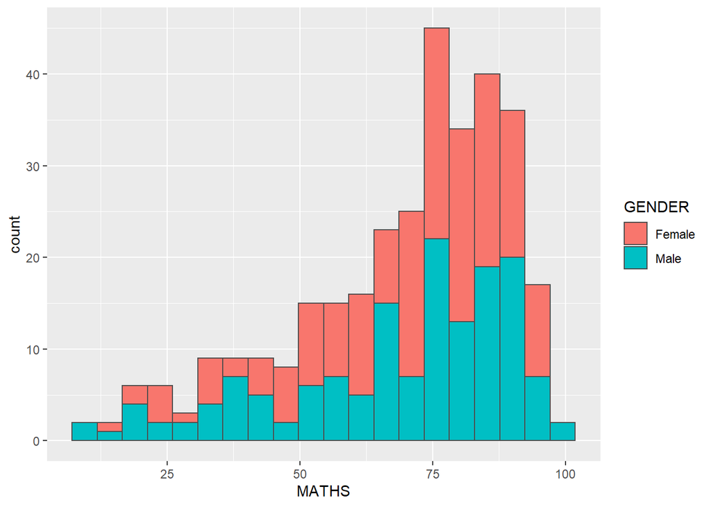

```r
exam_data %>%
  ggplot(aes(x=MATHS, fill=GENDER)) +
  geom_histogram(bins = 20,
                 color = "grey30")
```

#### geom_dotplot()

- dot plot (need x)

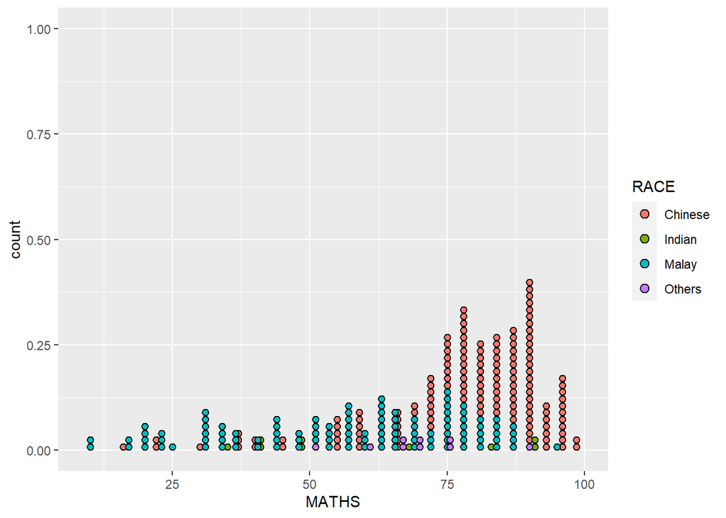

```r
exam_data %>%
  ggplot(aes(x=MATHS, fill=RACE)) +
  geom_dotplot(binwidth = 2.5, dotsize = 0.5)
```

### combine geometrics

sequence to sometimes important. e.g. for below, the boxplot is below the scatter point.

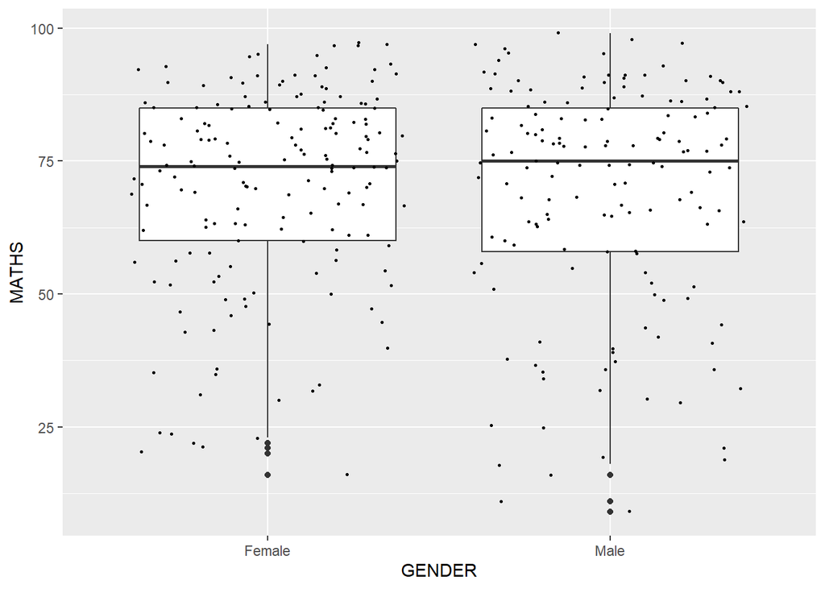

```r
exam_data %>%
  ggplot(aes(x=GENDER, y=MATHS)) +
  geom_boxplot() +
  geom_point(position='jitter', size=0.5)
```

# Interactivity with R: ggiraph

- tooltip: when hover, some information will appear
- Onclick: when click, it will jump to the link
- Data_id: when hover, the points with the same info will be highlighted
- It is shiny ready

Difference between ggplot2 and ggiraph:

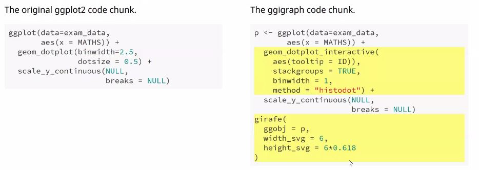

```r
knitr::include_graphics("img/diff_ggplot2_ggiraph.JPG")
```

```r
p <- exam_data %>%
  ggplot(aes(x=MATHS)) +
  geom_dotplot_interactive(aes(tooltip = CLASS, data_id = CLASS),
                           stackgroups=TRUE,
                           binwidth=1,
                           method='histodot') +
  scale_y_continuous(NULL, breaks=NULL)

girafe(
  ggobj=p,
  width_svg=6,
  height_svg = 6*0.618
)
```

[interactive chart not shown]